# Diagnostic evaluation in small sample conditions

**Study of statistical procedures for diagnostic evaluation in educational contexts** research team:

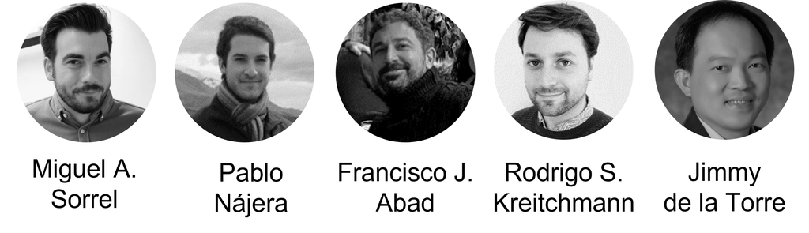

Some results:

<sup>4</sup> Nájera, P., Abad, F.J., Chiu, C-Y., & **Sorrel, M.A.** (manuscript accepted for publication). A Comprehensive Cognitive Diagnostic Method for Classroom-Level Assessments. *Journal of Educational and Behavioral Statistics*.

Here we propose a one-parameter CDM that can provides accurate classifications and posterior probabilities under small sample scenarios. The model is already available at the *cdmTools* R package, please check the *RDINA()* function at the package version at Github (https://github.com/Pablo-Najera/cdmTools/). We’ll submit shortly an updated version of the package to CRAN.

<sup>3</sup> Sanz, S., Kreitchmann, R. S., Nájera, P., Moreno, J. D., Martínez-Huertas, J. A., & Sorrel, M. A. (manuscript accepted for publication). FoCo: A Shiny app for formative assessment using cognitive diagnosis modeling. *Psicología Educativa*.

In this paper we examine the FoCo Shiny app to conduct CDM analysis. This is a user-friendly menu-based software in Spanish. The goal is to make CDM analysis more accesible to the broader audience and potential users.

You can find the app here: https://psychometricmodelling.shinyapps.io/FoCo/

<sup>2</sup> Kreitchmann, R. S., de la Torre, J., **Sorrel, M. A.**, Nájera, P., & Abad, F. J. (2022). Improving reliability estimation in cognitive diagnosis modeling. *Behavior Research Methods*, 1-15. https://doi.org/10.3758/s13428-022-01967-5

Item parameter estimates under small sample settings might be unreliable. Thus, in this paper we proposed a multiple imputation procedure to account for the item parameter uncertainty in the computation of classification accuracy measures.

This new procedure is available at the cdmTools R package. The only required input is a calibrated CDM using the GDINA R package:

cdmTools::CA.MI(GDINA.obj)

<sup>1</sup> Franco-Martínez, A., Alvarado, J., & **Sorrel, M. A.** (in press). Range restriction affects factor analysis: Normality, estimation, fit, loadings, and reliability. *Educational and Psychological Measurement*. https://doig.org/10.1177/00131644221081867

Range restriction is likely to happen when the sampling procedure is not random. In this paper we illustrate the implications that this might have in the context of factor analysis.